# PRISM Video Playlists

## PRISM Product Graph Editor (Oct 26)

[figure not shown]

**[Playlist: PRISM Product Graph Editor](https://www.youtube.com/playlist?list=PLSglZScsi7LA)** · 8 videos  
An eight-part tour of the Product Graph Editor, PRISM’s main web app. It covers where the app and engine live, the graph editor and its YAML files, then each results tab: inventory, impact analysis, process results, contribution tree and Sankey graphs, using the cotton fiber and jacket templates.

[figure not shown]

**1. [Introduction to Product Graph Editor](https://www.youtube.com/watch?v=DmLMN0XQrkU)**  
Where things live in the prism-lca org. The engine, life-cycle-assessment-mcp, is built on Brightway, runs on DigitalOcean, and has a REST API for the web app and an MCP for LLMs. The editor is JavaScript on GitHub Pages and rebuilds whenever main changes.

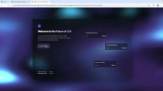

**2. [The Graph Editor - Structure Graph, Scaled Graph](https://www.youtube.com/watch?v=VImCZZTk-sI)**  
Sign in with Google, pick a template, and explore the cotton fiber and jacket graphs. The structure graph shows how activities connect; the scaled graph shows the amounts needed for the functional unit. Also covers reference amounts, elementary and technosphere flows, and graph controls.

[figure not shown]

**3. [Product Graph Yaml Files](https://www.youtube.com/watch?v=oOE0noTj0hM)**  
The Edit tab shows the model as a readable YAML file with the goal, functional unit, products, and each process’s inputs, outputs and emissions. The File menu loads templates, saves, downloads and uploads YAML files, shows edit history, and clears the session.

[figure not shown]

**4. [Inventory Results](https://www.youtube.com/watch?v=1MQ_rXXDIZ4)**  
Using the jacket graph, covers the global settings for decimal places and light or dark mode, then the LCA results summary: life cycle inventory totals and five TRACI impact scores. The Inventory tab lists total emissions and how much each process produces.

[figure not shown]

**5. [Impact Analysis](https://www.youtube.com/watch?v=q3j6pYukn-I)**  
The Impact Analysis tab breaks each impact category down by processes then flows, or flows then processes. Characterization factors show how scores are calculated: for climate change, each kilogram of methane counts 25 times as much as CO2, and everything is summed.

[figure not shown]

**6. [Process Results](https://www.youtube.com/watch?v=fbP868qBino)**  
Process Results looks at one activity at a time. The top shows its inputs and outputs; the bottom shows its share of each impact score, split into upstream and direct. For example, fabric weaving contributes 75% of climate change and 54% of acidification.

[figure not shown]

**7. [Contribution Tree Analysis](https://www.youtube.com/watch?v=BB8ZiB5HYng)**  
The contribution tree drills down from the functional unit to find hotspots. For the jacket’s climate change score, fabric weaving gives 75%, zipper production 8% and jacket assembly itself about 16%. Each row shows direct and accumulated contributions.

[figure not shown]

**8. [Sankey Graphs](https://www.youtube.com/watch?v=OUnZ5Y5gk8A)**  
The Sankey tab shows contributions as line thickness, by impact category or by flow, with filters for the number of processes and minimum share. Each card shows direct and upstream amounts, and clicking an activity highlights everything feeding into it.

## Life Cycle Assessment MCP Introduction (Jul 26)

[figure not shown]

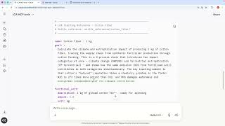

**1. [LCA Mcp Installation and Simple Cotton Fiber Case Study](https://www.youtube.com/watch?v=G52V_GB2wos)**  
Adds the LCA MCP to Claude.ai as a custom connector, lists its tools and the three mock case studies, and opens the cotton fiber product graph YAML. The structure graph introduces the functional unit, unit processes, and elementary flows: emissions and extractions.

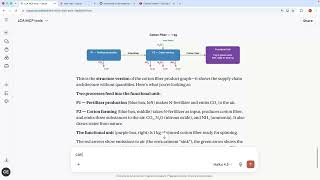

**2. [Product Graphs, Unit Processes, Inventory for LCAs](https://www.youtube.com/watch?v=LxIWEObPdfo)**  
Looks at the two cotton fiber unit processes one at a time, as they’d appear in a database like ecoinvent. Fertilizer production emits 3.5 kg of CO2 per kilogram; cotton farming needs 0.2 kg of fertilizer and 800 L of water per kilogram of fiber.

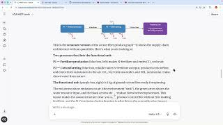

**3. [Running the LCA and Finding Inventory Results](https://www.youtube.com/watch?v=e1t2J7NOSrg)**  
Runs the LCA on the YAML file. The inventory totals each emission across processes: 1.5 kg CO2, 0.015 kg N2O, 0.01 kg NH3 and 800 L of water. The scaled graph shows activity levels, such as fertilizer production scaled by 0.2.

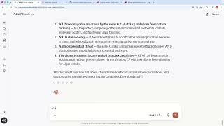

## OpenLCA and Mock LCA Tests (Jul 26)

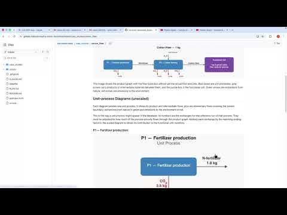

**[Playlist: OpenLCA and Mock LCA Tests](https://www.youtube.com/playlist?list=PLb9bj98Vo5cc)** · 3 videos  
Three videos on checking the Prism LCA engine against OpenLCA. They tour the case studies in the lca-mock-tests repo, install OpenLCA, and import the cotton fiber case study to confirm it gives the same inventory and TRACI 2.1 impact scores as the Prism MCP.

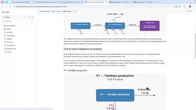

**1. [Mock LCA Tests Github Repo](https://www.youtube.com/watch?v=xZ0UToMz-NY)**  
A tour of the lca-mock-tests repo, used to check that the Brightway-based engine matches other LCA software. Each case study’s README shows its graphs, inventory and TRACI 2.1 scores, and release zip files hold each case study as an importable database.

[figure not shown]

**2. [Download OpenLCA Software](https://www.youtube.com/watch?v=x2OIwzgoflM)**  
A short guide to installing OpenLCA, a free, open-source desktop LCA app with good graphing and impact assessment tools. Download version 2.6.2 for your operating system from the openlca.org downloads page and install it before importing the case studies.

[figure not shown]

**3. [OpenLCA Cotton Fiber Product System](https://www.youtube.com/watch?v=lOUbUEJkMjs)**  
Creates an empty OpenLCA database, imports the cotton fiber zip from the repo’s releases, and calculates the product system with TRACI. The inventory (CO2 total of 1.5) and all four impact scores match the Prism results. Also tours the contribution tree and Sankey diagram.